# Lab week 1 - Tree-based methods

Data Science and Machine Learning 3 - CEU 2020

Jeno Pal

2020-02-19

```r
library(data.table)
library(caret)
library(rpart)
library(rpart.plot)
library(xgboost)
library(randomForest)
library(gbm)
library(ISLR)
library(skimr)
```

## Bagging, random forests

We covered decision trees in previous classes. Using it as a base model lets us build many different models with less variance and better predictive power. The downside: interpretation gets harder.

Idea: as individual trees are unstable and have high variance, train many versions on bootstrap samples (“Bagging”: Bootstrap AGGregation). Then predict: take the average (regression), majority vote / class share (classification).

Random forests: randomly constrain the set of predictor variables used to grow trees (randomly select at each split). Goal: avoid correlated trees that are very similar to each other, still with the aim of decreasing variance.

```r
data(Hitters)
data <- data.table(Hitters)
skim(data)
```

```
── Data Summary ────────────────────────
                           Values
Name                       data
Number of rows             322
Number of columns          20
_______________________
Column type frequency:
  factor                   3
  numeric                  17
________________________
Group variables            None

── Variable type: factor ──────────────────────────────────────────────────────────────────
  skim_variable n_missing complete_rate ordered n_unique top_counts
1 League                0             1 FALSE          2 A: 175, N: 147
2 Division              0             1 FALSE          2 W: 165, E: 157
3 NewLeague             0             1 FALSE          2 A: 176, N: 146

── Variable type: numeric ─────────────────────────────────────────────────────────────────
   skim_variable n_missing complete_rate    mean      sd    p0   p25    p50    p75  p100
 1 AtBat                 0         1      381.    153.    16   255.   380.   512     687
 2 Hits                  0         1      101.     46.5    1    64     96    137     238
 3 HmRun                 0         1       10.8     8.71   0     4      8     16      40
 4 Runs                  0         1       50.9    26.0    0    30.2   48     69     130
 5 RBI                   0         1       48.0    26.2    0    28     44     64.8   121
 6 Walks                 0         1       38.7    21.6    0    22     35     53     105
 7 Years                 0         1        7.44    4.93   1     4      6     11      24
 8 CAtBat                0         1     2649.   2324.    19   817.  1928   3924.  14053
 9 CHits                 0         1      718.    654.     4   209    508   1059.   4256
10 CHmRun                0         1       69.5    86.3    0    14     37.5   90     548
11 CRuns                 0         1      359.    334.     1   100.   247    526.   2165
12 CRBI                  0         1      330.    333.     0    88.8  220.   426.   1659
13 CWalks                0         1      260.    267.     0    67.2  170.   339.   1566
14 PutOuts               0         1      289.    281.     0   109.   212    325    1378
15 Assists               0         1      107.    137.     0     7     39.5  166     492
16 Errors                0         1        8.04    6.37   0     3      6     11      32
17 Salary               59         0.817  536.    451.    67.5 190    425    750    2460
   hist
 1 ▁▇▇▇▅
 2 ▃▇▆▃▁
 3 ▇▃▂▁▁
 4 ▅▇▆▃▁
 5 ▃▇▃▃▁
 6 ▅▇▅▂▁
 7 ▇▆▃▂▁
 8 ▇▃▂▁▁
 9 ▇▃▁▁▁
10 ▇▁▁▁▁
11 ▇▂▁▁▁
12 ▇▂▁▁▁
13 ▇▂▁▁▁
14 ▇▃▁▁▁
15 ▇▂▁▁▁
16 ▇▅▂▁▁
17 ▇▃▁▁▁
```

```r
# goal: predict log salary
data <- data[!is.na(Salary)]
data[, log_salary := log(Salary)]
data[, Salary := NULL]
```

```r
training_ratio <- 0.75
set.seed(1234)
train_indices <- createDataPartition(
  y = data[["log_salary"]],
  times = 1,
  p = training_ratio,
  list = FALSE
)
data_train <- data[train_indices, ]
data_test <- data[-train_indices, ]
```

Let’s see benchmarks: a linear model and a simple regression tree.

```r
set.seed(123)
train_control <- trainControl(
  method = "repeatedcv",
  number = 5,
  repeats = 3
)
set.seed(1234)
linear_model <- train(log_salary ~ .,
                      method = "lm",
                      data = data_train,
                      trControl = train_control)
linear_model
```

```
Linear Regression

200 samples
 19 predictor

No pre-processing
Resampling: Cross-Validated (5 fold, repeated 3 times)
Summary of sample sizes: 160, 161, 158, 160, 161, 160, ...
Resampling results:

  RMSE       Rsquared   MAE
  0.6501712  0.4839382  0.5264001

Tuning parameter 'intercept' was held constant at a value of TRUE
```

```r
set.seed(1234)
simple_tree_model <- train(log_salary ~ .,
                      method = "rpart",
                      data = data_train,
                      tuneGrid = data.frame(cp = c(0.01, 0.02, 0.05)),
                      trControl = train_control)
simple_tree_model
```

```
CART

200 samples
 19 predictor

No pre-processing
Resampling: Cross-Validated (5 fold, repeated 3 times)
Summary of sample sizes: 160, 161, 158, 160, 161, 160, ...
Resampling results across tuning parameters:

  cp    RMSE       Rsquared   MAE
  0.01  0.5438404  0.6344908  0.4039201
  0.02  0.5486396  0.6249884  0.4103041
  0.05  0.5596791  0.6110773  0.4284512

RMSE was used to select the optimal model using the smallest value.
The final value used for the model was cp = 0.01.
```

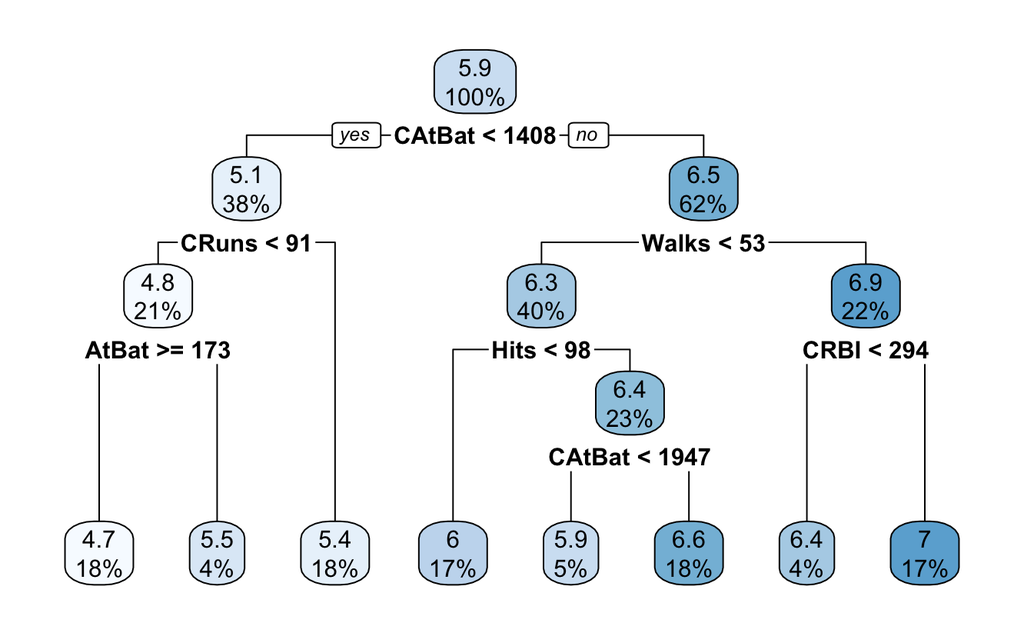

```r
rpart.plot(simple_tree_model[["finalModel"]])
```

For random forests, `mtry` sets the number of variables randomly chosen for any split in the tree. When `mtry` equals the number of features, it is the bagging.

```r
tune_grid <- expand.grid(
  .mtry = c(2, 3, 5, 7, 9, 12, 19),
  .splitrule = "variance",
  .min.node.size = c(5, 10)
)
# random forest
set.seed(1234)
rf_model <- train(log_salary ~ .,
                  method = "ranger",
                  data = data_train,
                  trControl = train_control,
                  tuneGrid = tune_grid,
                  importance = "impurity"
                  )
rf_model
```

```
Random Forest

200 samples
 19 predictor

No pre-processing
Resampling: Cross-Validated (5 fold, repeated 3 times)
Summary of sample sizes: 160, 161, 158, 160, 161, 160, ...
Resampling results across tuning parameters:

  mtry  min.node.size  RMSE       Rsquared   MAE
   2     5             0.4292981  0.7733745  0.3066962
   2    10             0.4307111  0.7738776  0.3086513
   3     5             0.4199588  0.7806929  0.2983449
   3    10             0.4216194  0.7796083  0.2992549
   5     5             0.4199923  0.7790641  0.2985019
   5    10             0.4163252  0.7839465  0.2963075
   7     5             0.4177797  0.7814325  0.2975971
   7    10             0.4186288  0.7803665  0.2980657
   9     5             0.4222687  0.7771253  0.3003027
   9    10             0.4214101  0.7780731  0.3017023
  12     5             0.4230200  0.7762746  0.3029079
  12    10             0.4234362  0.7753202  0.3018065
  19     5             0.4274207  0.7716985  0.3067756
  19    10             0.4261713  0.7726547  0.3066103

Tuning parameter 'splitrule' was held constant at a value of variance
RMSE was used to select the optimal model using the smallest value.
The final values used for the model were mtry = 5, splitrule = variance and
 min.node.size = 10.
```

```r
tune_grid <- expand.grid(
  .mtry = c(2, 3, 5),
  .splitrule = "variance",
  .min.node.size = 10
)
# the number of trees is not a tuning parameter with caret
# default is 500, you can change it with passing the parameter to train
set.seed(1234)
rf_model_ntree_10 <- train(log_salary ~ .,
                  method = "ranger",
                  data = data_train,
                  trControl = train_control,
                  tuneGrid = tune_grid,
                  num.trees = 10,
                  importance = "impurity"
                  )
rf_model_ntree_10
```

```
Random Forest

200 samples
 19 predictor

No pre-processing
Resampling: Cross-Validated (5 fold, repeated 3 times)
Summary of sample sizes: 160, 161, 158, 160, 161, 160, ...
Resampling results across tuning parameters:

  mtry  RMSE       Rsquared   MAE
  2     0.4538736  0.7479666  0.3305356
  3     0.4491221  0.7521932  0.3205821
  5     0.4466305  0.7504903  0.3204231

Tuning parameter 'splitrule' was held constant at a value of variance
Tuning
 parameter 'min.node.size' was held constant at a value of 10
RMSE was used to select the optimal model using the smallest value.
The final values used for the model were mtry = 5, splitrule = variance and
 min.node.size = 10.
```

```r
set.seed(1234)
rf_model_ntree_1000 <- train(
  log_salary ~ .,
  method = "ranger",
  data = data_train,
  trControl = train_control,
  tuneGrid = tune_grid,
  num.trees = 1000,
  importance = "impurity"
)
rf_model_ntree_1000
```

```
Random Forest

200 samples
 19 predictor

No pre-processing
Resampling: Cross-Validated (5 fold, repeated 3 times)
Summary of sample sizes: 160, 161, 158, 160, 161, 160, ...
Resampling results across tuning parameters:

  mtry  RMSE       Rsquared   MAE
  2     0.4311216  0.7730525  0.3092441
  3     0.4209541  0.7797607  0.2980373
  5     0.4186196  0.7809688  0.2976544

Tuning parameter 'splitrule' was held constant at a value of variance
Tuning
 parameter 'min.node.size' was held constant at a value of 10
RMSE was used to select the optimal model using the smallest value.
The final values used for the model were mtry = 5, splitrule = variance and
 min.node.size = 10.
```

```r
resamples(list(rf_model_ntree_10, rf_model, rf_model_ntree_1000)) %>%
  summary()
```

```
Call:
summary.resamples(object = .)

Models: Model1, Model2, Model3
Number of resamples: 15

MAE
            Min.   1st Qu.    Median      Mean   3rd Qu.      Max. NA's
Model1 0.2630441 0.2880203 0.3041409 0.3204231 0.3555424 0.3997506    0
Model2 0.2248343 0.2530310 0.2904198 0.2963075 0.3229744 0.4040080    0
Model3 0.2312051 0.2535274 0.2903592 0.2976544 0.3264849 0.4014512    0

RMSE
            Min.   1st Qu.    Median      Mean   3rd Qu.     Max. NA's
Model1 0.3594506 0.3892974 0.4370863 0.4466305 0.4835148 0.588991    0
Model2 0.2806319 0.3644820 0.4208052 0.4163252 0.4691900 0.541319    0
Model3 0.2916910 0.3661214 0.4307880 0.4186196 0.4676820 0.551900    0

Rsquared
            Min.   1st Qu.    Median      Mean   3rd Qu.      Max. NA's
Model1 0.6116841 0.7054863 0.7727967 0.7504903 0.8089861 0.8650301    0
Model2 0.6734545 0.7314981 0.7933756 0.7839465 0.8338789 0.9053532    0
Model3 0.6652557 0.7223720 0.7939706 0.7809688 0.8355901 0.8966369    0
```

```r
# calculate test error
RMSE(data_test[["log_salary"]], predict.train(rf_model, newdata = data_test))
```

```
[1] 0.4250089
```

(It is a small dataset hence performance measures can have large variances.)

### Out of bag error

Bootstrap samples: some observations are used more than once, some not at all. On average, around 1/3 of the observations are not used in a bootstrap sample.

Idea: for each sample point, obtain a random forest prediction from those trees where it was not used in the boostrap sample. Then comparing this prediction to reality gives an honest measure of performance.

```r
rf_model$finalModel
```

```
Ranger result

Call:
 ranger::ranger(dependent.variable.name = ".outcome", data = x,      mtry = min(param$mtry, ncol(x)), min.node.size = param$min.node.size,      splitrule = as.character(param$splitrule), write.forest = TRUE,      probability = classProbs, ...)

Type:                             Regression
Number of trees:                  500
Sample size:                      200
Number of independent variables:  19
Mtry:                             5
Target node size:                 10
Variable importance mode:         impurity
Splitrule:                        variance
OOB prediction error (MSE):       0.171978
R squared (OOB):                  0.7831491
```

```r
# the out of bag RMSE
sqrt(rf_model$finalModel$prediction.error)
```

```
[1] 0.4147023
```

We can base our model selection on OOB error instead of CV. It is generally faster as you do not have to re-estimate the same model many times, you just use the output of the `num.trees` trees that you estimate for RF.

```r
tune_grid <- expand.grid(
  .mtry = c(2, 3, 5, 7, 9, 12, 19),
  .splitrule = "variance",
  .min.node.size = c(5, 10)
)
train_control_oob <- trainControl(method = "oob")
# random forest
set.seed(1234)
rf_model_oob <- train(log_salary ~ .,
                  method = "ranger",
                  data = data_train,
                  trControl = train_control_oob,
                  tuneGrid = tune_grid,
                  importance = "impurity"
                  )
rf_model_oob
```

```
Random Forest

200 samples
 19 predictor

No pre-processing
Resampling results across tuning parameters:

  mtry  min.node.size  RMSE       Rsquared   MAE
   2     5             0.4308418  0.7682431  0.3003784
   2    10             0.4381368  0.7610405  0.3067427
   3     5             0.4164993  0.7818505  0.2893077
   3    10             0.4217959  0.7764587  0.2914613
   5     5             0.4232537  0.7735840  0.2945975
   5    10             0.4172621  0.7800882  0.2902756
   7     5             0.4188969  0.7783504  0.2911611
   7    10             0.4203516  0.7765478  0.2949455
   9     5             0.4199300  0.7773065  0.2929122
   9    10             0.4219191  0.7750108  0.2942116
  12     5             0.4263097  0.7704615  0.2990177
  12    10             0.4217148  0.7752375  0.2972123
  19     5             0.4251809  0.7717658  0.2989917
  19    10             0.4269421  0.7699722  0.2991765

Tuning parameter 'splitrule' was held constant at a value of variance
RMSE was used to select the optimal model using the smallest value.
The final values used for the model were mtry = 3, splitrule = variance and
 min.node.size = 5.
```

### Variable importance

With the ensemble models we have a hard time with interpretation. Variable importance measures can help to see which features contribute most to the predictive power of models. The generic `varImp` function of `caret` does model-specific calculations, consult [here](https://topepo.github.io/caret/variable-importance.html) for a description for your model at hand.

```r
varImp(rf_model)
```

```
ranger variable importance
```

|  | Overall |
| --- | --- |
| CAtBat | 100.00000000 |
| CHits | 96.79406318 |
| CRuns | 75.70249451 |
| CWalks | 53.71993589 |
| CRBI | 53.06633049 |
| CHmRun | 22.50982005 |
| Walks | 22.42044118 |
| Hits | 21.11383407 |
| Years | 20.71744327 |
| AtBat | 17.78706892 |

[output cut: 9 more lines]

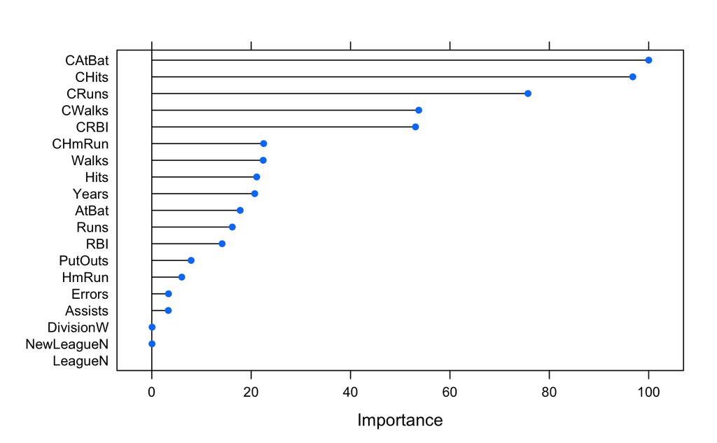

```r
plot(varImp(rf_model))
```

## Gradient boosting machines

Gradient boosting machines: also ensembles of trees, however, the method of choosing them is different. Idea: get the residual and train next tree to predict (explain) the residual. Then add it to the previous trees, with a shrinkage parameter (to avoid overfitting).

Another difference: GBMs use shallow trees (controlled by `interaction.depth`) whereas RFs use unpruned, large trees (with low bias and high variance). Common part: idea of bagging.

```r
gbm_grid <- expand.grid(n.trees = c(100, 500, 1000),
                        interaction.depth = c(2, 3, 5),
                        shrinkage = c(0.005, 0.01, 0.1),
                        n.minobsinnode = c(1))
set.seed(1234)
gbm_model <- train(log_salary ~ .,
                   method = "gbm",
                   data = data_train,
                   trControl = train_control,
                   tuneGrid = gbm_grid,
                   verbose = FALSE # gbm by default prints too much output
                   )
gbm_model
```

```
Stochastic Gradient Boosting

200 samples
 19 predictor

No pre-processing
Resampling: Cross-Validated (5 fold, repeated 3 times)
Summary of sample sizes: 160, 161, 158, 160, 161, 160, ...
Resampling results across tuning parameters:

  shrinkage  interaction.depth  n.trees  RMSE       Rsquared   MAE
  0.005      2                   100     0.6840716  0.6889846  0.5533104
  0.005      2                   500     0.4612991  0.7536647  0.3494607
  0.005      2                  1000     0.4371112  0.7622227  0.3242171
  0.005      3                   100     0.6641464  0.7352324  0.5396790
  0.005      3                   500     0.4443904  0.7657480  0.3326446
  0.005      3                  1000     0.4286722  0.7693528  0.3149624
  0.005      5                   100     0.6477246  0.7615636  0.5300118
  0.005      5                   500     0.4302013  0.7761544  0.3169845
  0.005      5                  1000     0.4221454  0.7755023  0.3059729
  0.010      2                   100     0.5732998  0.7189864  0.4535035
  0.010      2                   500     0.4368538  0.7622863  0.3242907
  0.010      2                  1000     0.4333661  0.7627714  0.3186413
  0.010      3                   100     0.5433476  0.7530570  0.4308607
  0.010      3                   500     0.4290259  0.7696129  0.3155583
  0.010      3                  1000     0.4295609  0.7672811  0.3132236
  0.010      5                   100     0.5258567  0.7669861  0.4170815
  0.010      5                   500     0.4214605  0.7767318  0.3053863
  0.010      5                  1000     0.4252530  0.7730785  0.3076256
  0.100      2                   100     0.4271046  0.7689369  0.3165587
  0.100      2                   500     0.4433781  0.7547982  0.3265697
  0.100      2                  1000     0.4493848  0.7488719  0.3295798
  0.100      3                   100     0.4421907  0.7539666  0.3233840
  0.100      3                   500     0.4575747  0.7401638  0.3307041
  0.100      3                  1000     0.4585745  0.7393870  0.3311904
  0.100      5                   100     0.4374729  0.7624210  0.3190774
  0.100      5                   500     0.4449132  0.7552548  0.3247914
  0.100      5                  1000     0.4450853  0.7550753  0.3249386

Tuning parameter 'n.minobsinnode' was held constant at a value of 1
RMSE was used to select the optimal model using the smallest value.
The final values used for the model were n.trees = 500, interaction.depth = 5, shrinkage
 = 0.01 and n.minobsinnode = 1.
```

```r
# we can refine the grid around the optimum found
gbm_grid_refined <- expand.grid(
  n.trees = c(250, 500, 1000),
  interaction.depth = c(5, 7, 9),
  shrinkage = c(0.005, 0.01, 0.02, 0.05),
  n.minobsinnode = c(1)
)
set.seed(1234)
gbm_model_refined <- train(log_salary ~ .,
                   method = "gbm",
                   data = data_train,
                   trControl = train_control,
                   tuneGrid = gbm_grid_refined,
                   verbose = FALSE # gbm by default prints too much output
                   )
gbm_model_refined
```

```
Stochastic Gradient Boosting

200 samples
 19 predictor

No pre-processing
Resampling: Cross-Validated (5 fold, repeated 3 times)
Summary of sample sizes: 160, 161, 158, 160, 161, 160, ...
Resampling results across tuning parameters:

  shrinkage  interaction.depth  n.trees  RMSE       Rsquared   MAE
  0.005      5                   250     0.4907541  0.7689692  0.3812939
  0.005      5                   500     0.4312671  0.7749117  0.3181426
  0.005      5                  1000     0.4221168  0.7762660  0.3061468
  0.005      7                   250     0.4870341  0.7702973  0.3780803
  0.005      7                   500     0.4280137  0.7766513  0.3150528
  0.005      7                  1000     0.4214972  0.7768845  0.3061767
  0.005      9                   250     0.4819622  0.7756709  0.3737817
  0.005      9                   500     0.4247556  0.7792006  0.3124206
  0.005      9                  1000     0.4197791  0.7784561  0.3043838
  0.010      5                   250     0.4313351  0.7747053  0.3173581
  0.010      5                   500     0.4222384  0.7758528  0.3063814
  0.010      5                  1000     0.4266339  0.7714577  0.3075532
  0.010      7                   250     0.4256657  0.7788142  0.3125624
  0.010      7                   500     0.4196587  0.7786732  0.3026210
  0.010      7                  1000     0.4242432  0.7746908  0.3051970
  0.010      9                   250     0.4265682  0.7776990  0.3111629
  0.010      9                   500     0.4213848  0.7776738  0.3033841
  0.010      9                  1000     0.4248527  0.7749663  0.3060748
  0.020      5                   250     0.4235701  0.7739122  0.3102003
  0.020      5                   500     0.4285392  0.7692457  0.3126995
  0.020      5                  1000     0.4345301  0.7634859  0.3162911
  0.020      7                   250     0.4258248  0.7728433  0.3094907
  0.020      7                   500     0.4294962  0.7699405  0.3118319
  0.020      7                  1000     0.4338095  0.7657542  0.3145907
  0.020      9                   250     0.4221722  0.7767517  0.3067410
  0.020      9                   500     0.4257077  0.7739645  0.3078796
  0.020      9                  1000     0.4287479  0.7712968  0.3096631
  0.050      5                   250     0.4378810  0.7601855  0.3168161
  0.050      5                   500     0.4427621  0.7555992  0.3200748
  0.050      5                  1000     0.4443595  0.7539009  0.3213235
  0.050      7                   250     0.4363808  0.7631457  0.3168341
  0.050      7                   500     0.4397647  0.7596037  0.3188720
  0.050      7                  1000     0.4403053  0.7590124  0.3191292
  0.050      9                   250     0.4362130  0.7636038  0.3215189
  0.050      9                   500     0.4373871  0.7624266  0.3223128
  0.050      9                  1000     0.4375777  0.7622111  0.3224810

Tuning parameter 'n.minobsinnode' was held constant at a value of 1
RMSE was used to select the optimal model using the smallest value.
The final values used for the model were n.trees = 500, interaction.depth = 7, shrinkage
 = 0.01 and n.minobsinnode = 1.
```

Lower `eta` means slower learning, hence more trees are necessary to have good performance.

4 hyperparameters: [the curse of dimensionality](https://en.wikipedia.org/wiki/Curse_of_dimensionality) can make it hard to come up with efficient grids for hyperparameter search. However, with `gbm` and many other models, in reality the models to be estimated are not exponentially growing with the number of hyperparameters (see [here](https://topepo.github.io/caret/random-hyperparameter-search.html)).

The variable importance profile is typically more extreme than for random forests. This is not a contradiction or a problem, just a property of the models and ultimately different faces of the data.

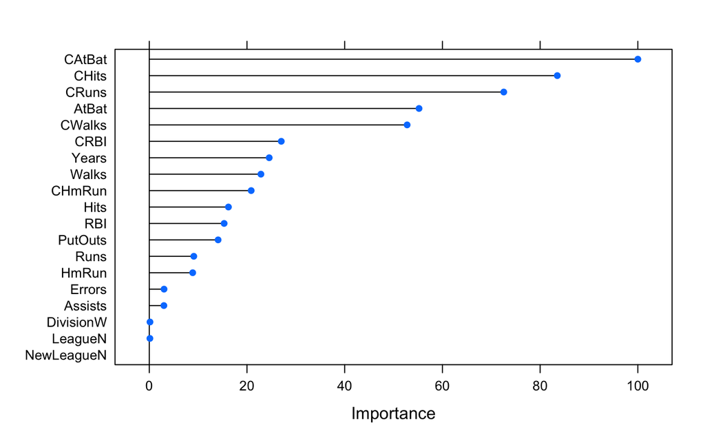

```r
plot(varImp(gbm_model))
```

Not tuned: `bag.fraction` parameter (set to default 0.5): for the construction of each tree, only `bag.fraction` share of the sample is used (randomly selected, see `?gbm`). This, again, is the same idea as with bagging: decrease variance of the model. You can pass another value for it via giving `train` an argument `bag.fraction`, just like we saw with `ranger` and `num.trees`.

```r
gbm_grid_2 <- data.frame(n.trees = c(1000),
                         interaction.depth = c(7),
                         shrinkage = c(0.005),
                         n.minobsinnode = c(5))
set.seed(1234)
gbm_model_2 <- train(log_salary ~ .,
                   method = "gbm",
                   data = data_train,
                   trControl = train_control,
                   tuneGrid = gbm_grid_2,
                   bag.fraction = 0.8,
                   verbose = FALSE # gbm by default prints too much output
                   )
gbm_model_2
```

```
Stochastic Gradient Boosting

200 samples
 19 predictor

No pre-processing
Resampling: Cross-Validated (5 fold, repeated 3 times)
Summary of sample sizes: 160, 161, 158, 160, 161, 160, ...
Resampling results:

  RMSE       Rsquared   MAE
  0.4846663  0.7052494  0.338657

Tuning parameter 'n.trees' was held constant at a value of 1000
Tuning
 parameter 'shrinkage' was held constant at a value of 0.005
Tuning
 parameter 'n.minobsinnode' was held constant at a value of 5
```

### XGBoost

A celebrated implementation of the gradient boosting idea. *“Both xgboost and gbm follows the principle of gradient boosting. There are however, the difference in modeling details. Specifically, xgboost used a more regularized model formalization to control over-fitting, which gives it better performance.”*

See documentation [here](http://xgboost.readthedocs.io/). It proved to be very stable and widely applicable. For the many hyperparameters, consult the documentation. New ones compared to prevoiusly seen `gbm`: * `colsample_bytree`: constrain number of columns to use to build a tree in a step

```r
xgb_grid <- expand.grid(nrounds = c(500, 1000),
                       max_depth = c(2, 3, 5),
                       eta = c(0.01, 0.05),
                       gamma = 0,
                       colsample_bytree = c(0.5, 0.7),
                       min_child_weight = 1, # similar to n.minobsinnode
                       subsample = c(0.5))
set.seed(1234)
xgboost_model <- train(log_salary ~ .,
                       method = "xgbTree",
                       data = data_train,
                       trControl = train_control,
                       tuneGrid = xgb_grid)
xgboost_model
```

```
eXtreme Gradient Boosting

200 samples
 19 predictor

No pre-processing
Resampling: Cross-Validated (5 fold, repeated 3 times)
Summary of sample sizes: 160, 161, 158, 160, 161, 160, ...
Resampling results across tuning parameters:

  eta   max_depth  colsample_bytree  nrounds  RMSE       Rsquared   MAE
  0.01  2          0.5                500     0.4457877  0.7548280  0.3237106
  0.01  2          0.5               1000     0.4224792  0.7739140  0.3080871
  0.01  2          0.7                500     0.4512877  0.7495286  0.3260174
  0.01  2          0.7               1000     0.4274222  0.7695547  0.3107760
  0.01  3          0.5                500     0.4432222  0.7589914  0.3178872
  0.01  3          0.5               1000     0.4205234  0.7777068  0.3037023
  0.01  3          0.7                500     0.4499673  0.7516189  0.3210616
  0.01  3          0.7               1000     0.4268872  0.7704529  0.3075166
  0.01  5          0.5                500     0.4466527  0.7576306  0.3178487
  0.01  5          0.5               1000     0.4213282  0.7779071  0.3039778
  0.01  5          0.7                500     0.4517355  0.7530411  0.3197829
  0.01  5          0.7               1000     0.4249968  0.7746115  0.3064693
  0.05  2          0.5                500     0.4340363  0.7634959  0.3156663
  0.05  2          0.5               1000     0.4452889  0.7522839  0.3245901
  0.05  2          0.7                500     0.4354877  0.7613028  0.3168138
  0.05  2          0.7               1000     0.4463208  0.7502070  0.3251374
  0.05  3          0.5                500     0.4252604  0.7721231  0.3102496
  0.05  3          0.5               1000     0.4285889  0.7691576  0.3120658
  0.05  3          0.7                500     0.4341316  0.7643782  0.3174513
  0.05  3          0.7               1000     0.4378311  0.7603843  0.3201419
  0.05  5          0.5                500     0.4277463  0.7714049  0.3117413
  0.05  5          0.5               1000     0.4281300  0.7710232  0.3120421
  0.05  5          0.7                500     0.4368027  0.7638426  0.3161813
  0.05  5          0.7               1000     0.4371288  0.7635712  0.3164328

Tuning parameter 'gamma' was held constant at a value of 0
Tuning
 parameter 'min_child_weight' was held constant at a value of 1
Tuning
 parameter 'subsample' was held constant at a value of 0.5
RMSE was used to select the optimal model using the smallest value.
The final values used for the model were nrounds = 1000, max_depth = 3, eta = 0.01,
 gamma = 0, colsample_bytree = 0.5, min_child_weight = 1 and subsample = 0.5.
```

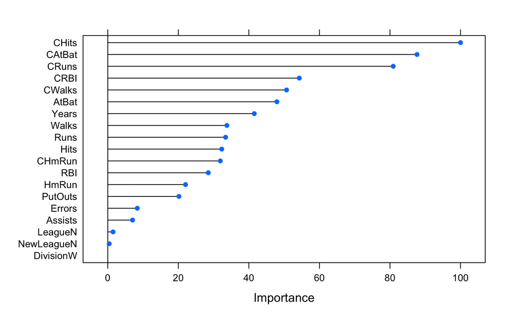

```r
plot(varImp(xgboost_model))
```

```r
resamples_object <- resamples(list("rpart" = simple_tree_model,
                                   "rf" = rf_model,
                                   "gbm" = gbm_model,
                                   "xgboost" = xgboost_model))
summary(resamples_object)
```

[output not shown]